# La Transizione Energetica Globale 🌎

Analisi della produzione di energia elettrica di 50 paesi (2000–2024)

[figure not shown]

PROGETTO DI FONDAMENTI DI SCIENZA DEI DATI E LABORATORIO

Massimiliano Caruzzi

# Perché analizzare la transizione energetica?

- L'interesse per i temi della sostenibilità e dell'energia
- L'interesse nell'applicare strumenti di Data Science a un problema reale e di attualità
- Capire come sta cambiando la produzione di energia nel mondo
- Capire la situazione dell'Italia in termini di produzione elettrica

# Dataset utilizzati

## World Energy Transition 2000–2025

- **Autore:** Syed Ali Taqi
- **Fonte:** Kaggle
- **Riferimento online:** [Pagina del dataset](https://www.kaggle.com/datasets/alitaqishah/world-energy-transition-20002025/data)
- **Descrizione:** Dataset sulla transizione energetica globale dei 50 principali paesi produttori di elettricità (2000–2025), contenente dati su produzione energetica, fonti rinnovabili e fossili, emissioni di CO₂ evitate, tassi di crescita e principali politiche energetiche internazionali

**Note:** Poiché il dataset presentava dati mancanti per alcuni paesi nell'anno 2025, l'analisi è stata condotta utilizzando esclusivamente i dati disponibili fino al 2024.

## Natural Earth

- **Fonte:** Natural Earth
- **Riferimento online:** [Pagina del dataset](https://www.naturalearthdata.com)
- **Descrizione:** Dataset cartografico open source contenente dati geografici vettoriali e raster utilizzati come base per la realizzazione di mappe
- [Download](https://naciscdn.org/naturalearth/packages/Natural_Earth_quick_start.zip)

# Dati rilevanti

- Identificazione (Paese,Anno)
- Produzione elettrica (Produzione Totale di Elettricità, Domanda di elettricità)
- Fonti energetiche (Energia Solare, Energia Eolica, Energia Idroelettrica, Energia da fonti fossili, Energia Nucleare,Energia totale da Rinnovabili)
- Indicatori ambientali (Intensità di Carbonio)
- Quote del mix energetico (Quota Rinnovabili, Quota Fossile)

# Domande

1. Come è cambiato il sistema elettrico mondiale tra il 2000 e il 2024?
2. Quali Paesi hanno registrato la crescita più rapida della quota di energia rinnovabile?
3. Quali benefici ha portato la diffusione delle energie rinnovabili?
4. Quali Paesi hanno prodotto più elettricità nel 2024 e quale ruolo ricoprono le energie rinnovabili?
5. Come si è evoluto il sistema elettrico italiano tra il 2000 e il 2024?
6. Qual è la situazione del sistema elettrico italiano nel 2024?

# Analisi Effettuate

Come è cambiato il sistema elettrico mondiale tra il 2000 e il 2024?

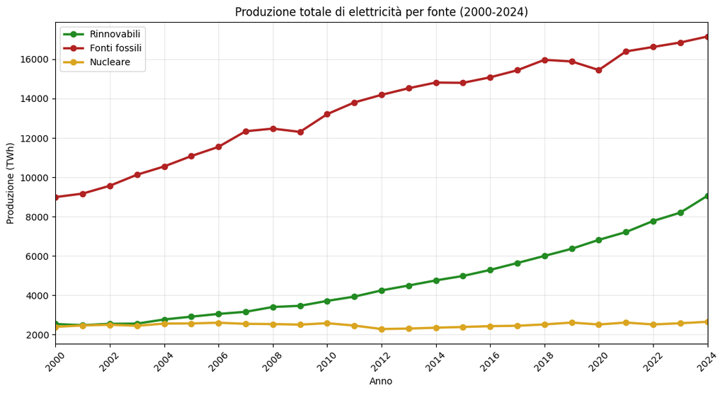

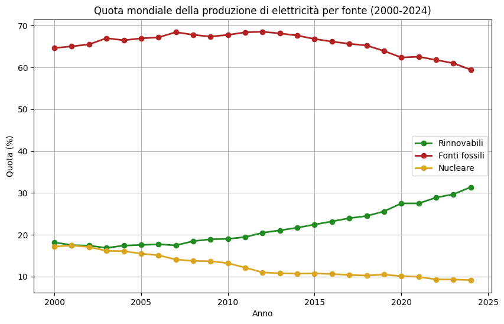

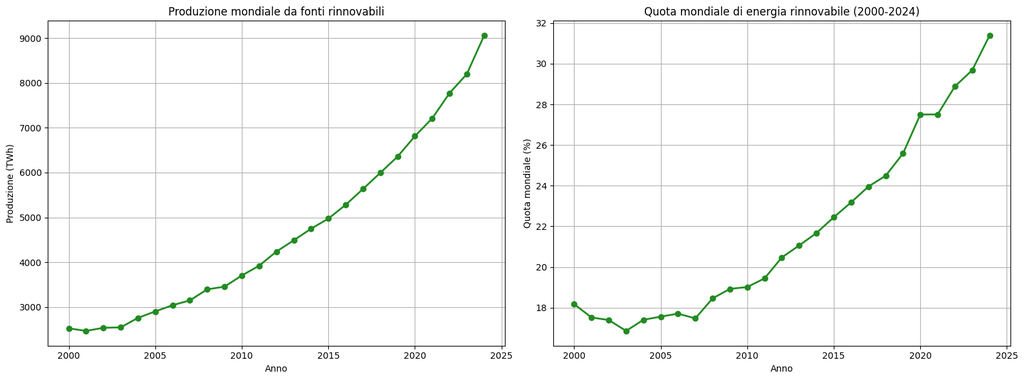

Quali Paesi hanno registrato la crescita più rapida della quota di energia rinnovabile?

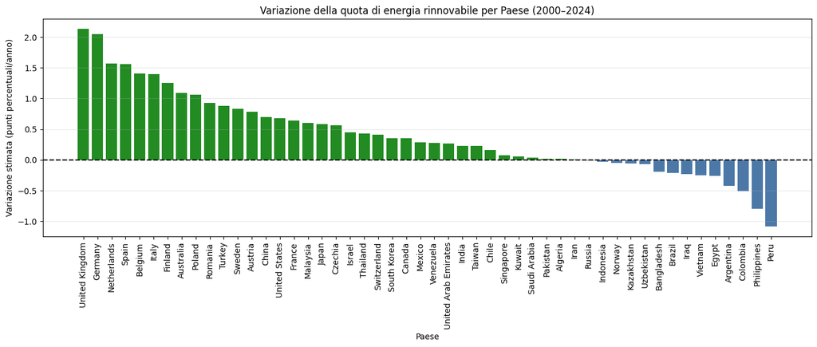

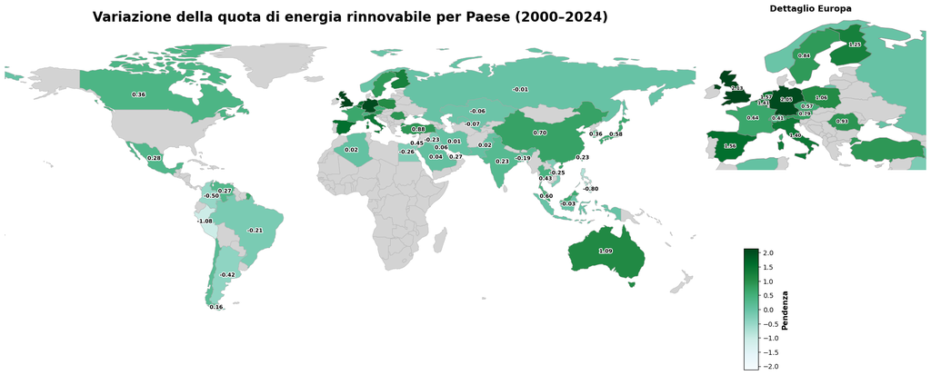

Quali benefici ha portato la diffusione delle energie rinnovabili?

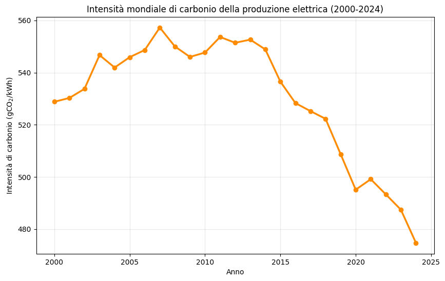

Quali Paesi hanno prodotto più elettricità nel 2024 e quale ruolo ricoprono le energie rinnovabili?

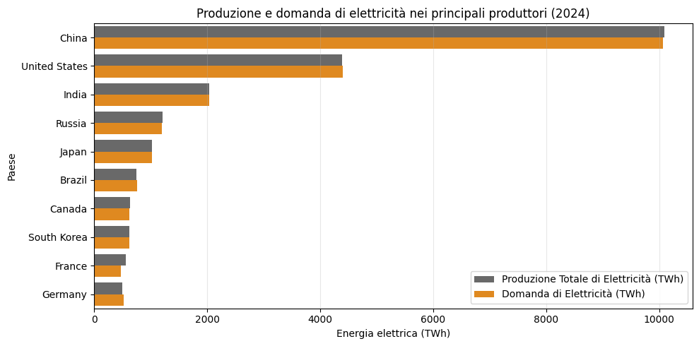

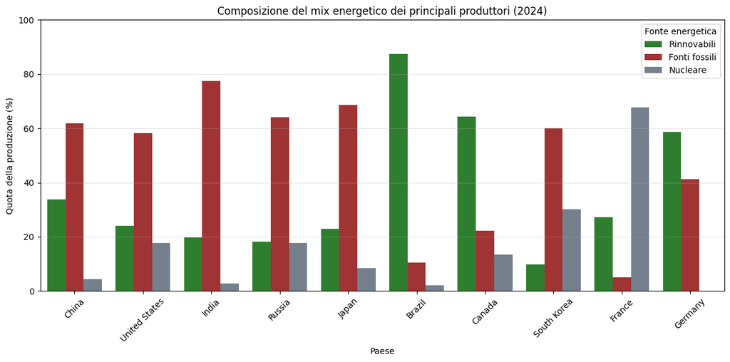

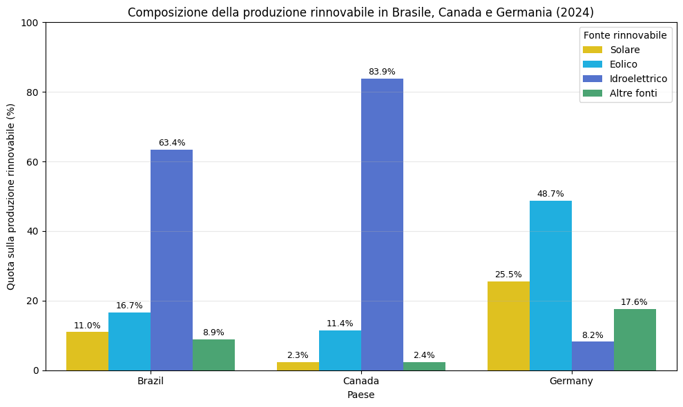

# E l'Italia?

|  | Paese | Anno | Produzione Totale di Elettricità (TWh) |
| --- | --- | --- | --- |
| 1 | China | 2024 | 10086.880000 |
| 2 | United States | 2024 | 4391.020000 |
| 3 | India | 2024 | 2036.520000 |
| 4 | Russia | 2024 | 1209.310000 |
| 5 | Japan | 2024 | 1016.390000 |
| 6 | Brazil | 2024 | 745.720000 |
| 7 | Canada | 2024 | 636.790000 |
| 8 | South Korea | 2024 | 625.380000 |
| 9 | France | 2024 | 561.780000 |
| 10 | Germany | 2024 | 495.990000 |
| 21 | Italy | 2024 | 267.560000 |

Come si è evoluto il sistema elettrico italiano tra il 2000 e il 2024?

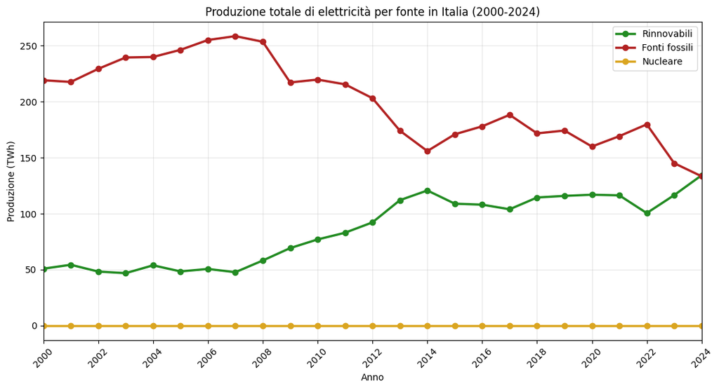

[figure not shown]

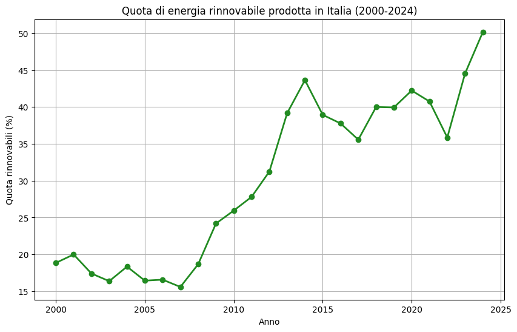

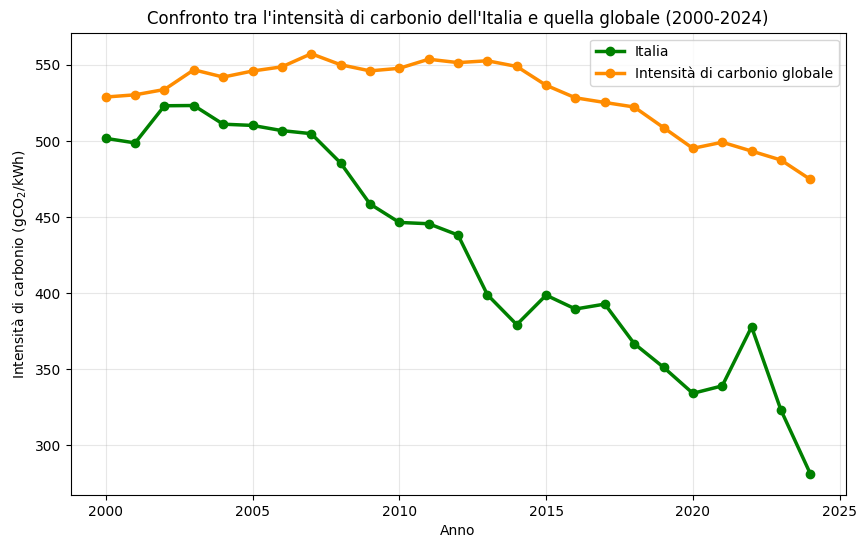

Qual è la situazione del sistema elettrico italiano nel 2024?

| Mix energetico | Bilancio elettrico |
| --- | --- |
| Rinnovabili 50.2 % | Produzione 267.6 TWh |
| Fonti fossili 49.8 % | Domanda 318.6 TWh |
| Nucleare 0.0 % | Importazioni 51.0 TWh |

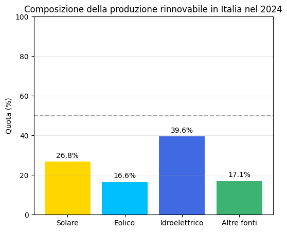